# Species Sensitivity Distribution Analysis Demonstration

Joe Thorley

February 14th, 2018

## Introduction

This script demonstrates the use of the `ssdca` package to perform a species sensitivity distribution analysis consistent with the associated shiny app with confidence intervals.

To get more information on a function type `?` followed by the name of the function.

## Demonstration

### ssdca

First, install and then load the `ssdca` R package.

```
install.packages("devtools")
devtools::install_github("bcgov/ssdca")
```

```r
library(ssdca)
```

### Data

Next, load the data set.

```r
file <- system.file("extdata", "boron_data.csv", package = "ssdca")
data <- read.csv(file)
head(data)
```

```
##   Chemical               Species Conc Group Units
## 1    Boron   Oncorhynchus mykiss  2.1  Fish  mg/L
## 2    Boron   Ictalurus punctatus  2.4  Fish  mg/L
## 3    Boron Micropterus salmoides  4.1  Fish  mg/L
## 4    Boron     Brachydanio rerio 10.0  Fish  mg/L
## 5    Boron     Carassius auratus 15.6  Fish  mg/L
## 6    Boron   Pimephales promelas 18.3  Fish  mg/L
```

### Fit

Then fit one or more distributions to the data. Don’t forget to specify the column with the concentration values.

```r
fits <- ssd_fit_dists(data, left = "Conc",
                      dists = c("lnorm", "llog", "gompertz", "lgumbel", "gamma", "weibull"))
```

The `autoplot()` function can be used to plot the fits (for more information type `?autoplot.fitdists`)

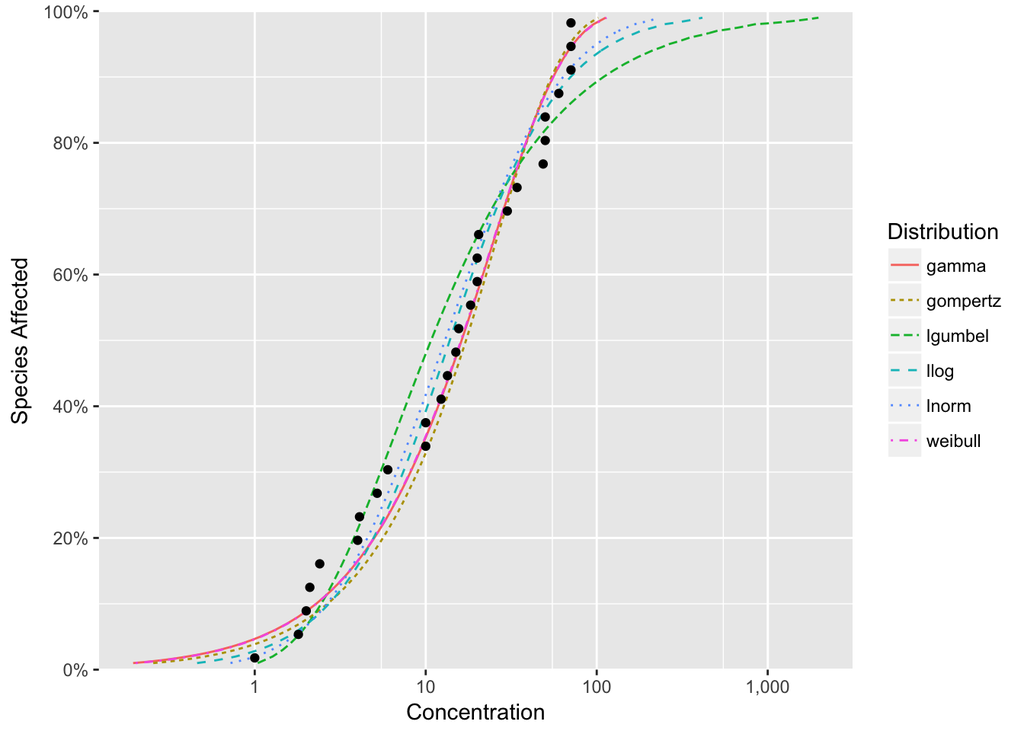

```r
autoplot(fits)
```

And `ssd_gof()` can be used to generate the goodness of fit statistics.

```r
ssd_gof(fits)
```

```
## # A tibble: 6 x 9
##   dist        ad     ks    cvm   aic  aicc   bic  delta weight
##   <chr>    <dbl>  <dbl>  <dbl> <dbl> <dbl> <dbl>  <dbl>  <dbl>
## 1 lnorm    0.507 0.107  0.0703   239   240   242 1.42   0.133
## 2 llog     0.487 0.0993 0.0595   241   241   244 3.40   0.0490
## 3 gompertz 0.602 0.120  0.0822   238   238   240 0      0.271
## 4 lgumbel  0.829 0.158  0.134    244   245   247 6.58   0.0100
## 5 gamma    0.441 0.117  0.0555   238   238   240 0.0190 0.268
## 6 weibull  0.435 0.117  0.0543   238   238   240 0.0140 0.269
```

### Predict

The following code block does not use confidence intervals therefore we can use just 10 bootstrap samples when generating the predictions - unlike the upper and lower confidence limits, the precision of the estimates is not affected by the number of bootstrap samples. For more information type `?predict.fitdists`

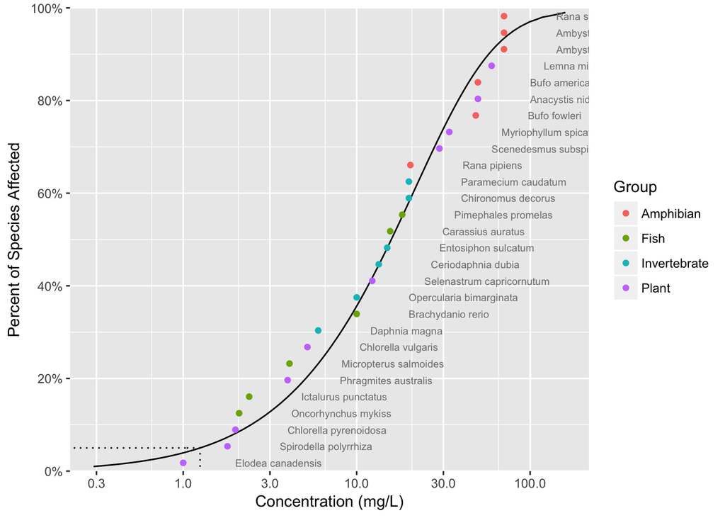

```r
pred <- predict(fits, nboot = 10L)

ssd_plot(data, pred, left = "Conc", label = "Species", color = "Group",
         xlab = "Concentration (mg/L)", ci = FALSE, hc = 5L, shift = 2)
```

### Hazard Concentration

To get precise confidence limits on the hazard concentration use at least 10,000 bootstrap samples. Here for demonstrative purposes just 100 samples are used.

```r
ssd_hc(fits, nboot = 100L)
```

```
## # A tibble: 1 x 5
##   percent   est    se   lcl   ucl
##     <int> <dbl> <dbl> <dbl> <dbl>
## 1       5  1.25 0.730 0.654  3.15
```

### Confidence Intervals

To generate and plot precise confidence intervals run the following code. It will take around 5-10 hours to complete

```
 pred <- predict(fits, nboot = 10000L)
 ssd_plot(data, pred, left = "Conc", label = "Species", color = "Group",
          xlab = "Concentration (mg/L)", hc = 5)
```